# Annotation of clusters in 10x data

Arun Chavan

Started: 2020-09-02  
Last edited: 2020-09-07 14:20:19

```r
### packages ==================================================================
library(tidyverse)

# single cell
library(Seurat)

# rmd
library(kableExtra)

# plotting
library(patchwork)
library(ggthemes)
```

We can take a first pass at annotating the clusters from our 10x data by comparing them to the reference dataset that we put together. This was done by compiling celltype-averaged expression values from the following single cell RNA-seq studies: (Pavličev et al. 2017; Vento-Tormo et al. 2018; Suryawanshi et al. 2018).

# 1 Data

## 1.1 Samples

```r
sample.info <- read.delim("../info/from-alice/sample_info.tsv", stringsAsFactors = FALSE)
sample.info %>% kable(caption = "Sample information") %>% kable_styling(full_width = FALSE)
```

Sample information

| sample_id | inp_id | covid | tissue |
| --- | --- | --- | --- |
| AL01 | INP88 | covid | decidua |
| AL02 | INP88 | covid | villi |
| AL03 | INP90 | covid | decidua |
| AL04 | INP90 | covid | villi |
| AL05 | INP187 | cntrl | decidua |
| AL06 | INP187 | cntrl | villi |
| AL07 | INP188 | cntrl | decidua |
| AL08 | INP188 | cntrl | villi |
| AL09 |  | cntrl | decidua |
| AL10 |  | cntrl | decidua |

## 1.2 Seurat-processed data

Read the `Seurat`-processed (by Eric) data sent by Alice.

```r
seur <- readRDS("../info/from-alice/placenta.rds")

head(seur@meta.data)
```

|  | orig.ident | nCount_RNA | nFeature_RNA | percent.mt | nCount_SCT | nFeature_SCT | integrated_snn_res.0.9 | seurat_clusters | sub |
| --- | --- | --- | --- | --- | --- | --- | --- | --- | --- |
| AAACCCAAGAAGCCTG_1 | AL1 | 5662 | 2085 | 3.638290 | 6031 | 2085 | 18 | 18 | AL1_18 |
| AAACCCAAGTGATTCC_1 | AL1 | 8437 | 2631 | 7.810833 | 7070 | 2629 | 19 | 19 | AL1_19 |
| AAACCCATCGTTGTAG_1 | AL1 | 19772 | 4318 | 2.447906 | 7203 | 2649 | 12 | 12 | AL1_12 |
| AAACCCATCTGAATGC_1 | AL1 | 3516 | 1578 | 2.019340 | 5695 | 1582 | 7 | 7 | AL1_7 |
| AAACGAAAGCTCTGTA_1 | AL1 | 23214 | 5035 | 1.731714 | 6775 | 2600 | 4 | 4 | AL1_4 |
| AAACGAAAGGTCACTT_1 | AL1 | 4367 | 1616 | 12.800550 | 5716 | 1614 | 1 | 1 | AL1_1 |

The `orig.ident` column in the metadata represents the sample IDs from the sample info table above. We just have rename them to left-pad the numbers for consistency, and set new cluster names as default idents.

```r
# left pad orig.idents
seur@meta.data$orig.ident <- gsub("(AL)(\\d)$", "\\10\\2", seur@meta.data$orig.ident)

# add additional metadata (covid status, tissue)
seur@meta.data$covid <- sample.info$covid[match(x = seur@meta.data$orig.ident,
                                                table = sample.info$sample_id)]
seur@meta.data$tissue <- sample.info$tissue[match(x = seur@meta.data$orig.ident,
                                                  table = sample.info$sample_id)]

# rename clusters for consistency
seur$seurat_clusters <- paste0("clust_", seur$seurat_clusters)
seur$seurat_clusters <- gsub("(clust_)(\\d$)", "\\10\\2", as.character(seur$seurat_clusters)) # left pad
seur$seurat_clusters <- factor(seur$seurat_clusters, levels = paste0("clust_", c("00", "01", "02", "03", "04", "05", "06", "07", "08", "09", 10:34)))

# set seurat clusters as default idents
Idents(seur) <- seur@meta.data$seurat_clusters
```

## 1.3 Average by cluster

We have to get transcriptomes averaged by clusters, so that we can compare them with the reference data in order to narrow down annotations. For averaging, we will use `sctransform` normalized data since this is what we use for marker gene detection down the line.

```r
# average sctransformed expression
seur.avg <- AverageExpression(seur)

# averaged data to use for correlations (SCT transformed)
plac <- seur.avg$SCT
```

## 1.4 Reference data

```r
# read reference datasets
ref <- read.csv("../results/01_reference-atlas/vento-surya-pavli_joined.csv", stringsAsFactors = FALSE)
```

## 1.5 Get data in shape

We will join the data with the reference data so they are both in the same dataframe.

```r
# add gene names column
plac$gene_name <- rownames(plac)

# inner join
plac <- dplyr::inner_join(plac, ref, by = "gene_name")

head(plac)
```

|  | clust_00 | clust_01 | clust_02 | clust_03 | clust_04 | clust_05 | clust_06 | clust_07 | clust_08 | clust_09 | clust_10 | clust_11 | clust_12 | clust_13 | clust_14 | clust_15 | clust_16 | clust_17 | clust_18 | clust_19 | clust_20 | clust_21 | clust_22 | clust_23 | clust_24 | clust_25 | clust_26 | clust_27 | clust_28 | … |
| --- | --- | --- | --- | --- | --- | --- | --- | --- | --- | --- | --- | --- | --- | --- | --- | --- | --- | --- | --- | --- | --- | --- | --- | --- | --- | --- | --- | --- | --- | --- |
| 1 | 0.143639684 | 0.003628333 | 0.053664648 | 0.0015040825 | 0.017019420 | 0.019450523 | 0.031404550 | 0.04372671 | 0.003130336 | 0.007122507 | 0.006176471 | 0.008507853 | 0.015961138 | 0.02889359 | 0.008330178 | 0.0292 | 0.000000000 | 0.001410437 | 0.146618482 | 0.014606155 | 0.0031152648 | 0.013354281 | 0.002923977 | 0.004246285 | 0.000000000 | 0.000000000 | 0.00000000 | 0.004322767 | 0.00000000 | … |
| 2 | 0.081436397 | 0.106483673 | 0.062225934 | 0.0111731844 | 0.077241981 | 0.103087770 | 0.115232443 | 0.10559006 | 0.094479226 | 0.139601140 | 0.142941176 | 0.082460733 | 0.078764747 | 0.08104299 | 0.110942825 | 0.0716 | 0.046931408 | 0.033850494 | 0.063500258 | 0.088158581 | 0.1191588785 | 0.100549882 | 0.034113060 | 0.105095541 | 0.015945330 | 0.047729919 | 0.02130178 | 0.123919308 | 0.01083032 | … |
| 3 | 0.008155813 | 0.012147026 | 0.007099603 | 0.0008594757 | 0.005891338 | 0.007537078 | 0.013847676 | 0.01540373 | 0.008537279 | 0.006267806 | 0.011470588 | 0.006544503 | 0.010409438 | 0.01127555 | 0.006815600 | 0.0092 | 0.002005616 | 0.002350729 | 0.008776458 | 0.006259781 | 0.0070093458 | 0.009426551 | 0.005847953 | 0.008492569 | 0.004555809 | 0.005820722 | 0.00000000 | 0.015850144 | 0.00000000 | … |
| 4 | 0.014972611 | 0.001104275 | 0.011275840 | 0.0010743446 | 0.006545931 | 0.036469730 | 0.005934718 | 0.00447205 | 0.007398976 | 0.016239316 | 0.018823529 | 0.007198953 | 0.009368494 | 0.01057082 | 0.028019690 | 0.0100 | 0.004011231 | 0.001880583 | 0.009292721 | 0.003651539 | 0.0007788162 | 0.002356638 | 0.003898635 | 0.010615711 | 0.000000000 | 0.002328289 | 0.00000000 | 0.000000000 | 0.00000000 | … |
| 5 | 0.127571516 | 0.030761950 | 0.085612863 | 0.0818650623 | 0.396901593 | 0.051057622 | 0.086547972 | 0.17242236 | 0.097040410 | 0.040740741 | 0.075000000 | 0.062172775 | 0.096113810 | 0.11980268 | 0.052252934 | 0.1128 | 0.030084236 | 0.014574518 | 0.129065565 | 0.771517997 | 0.0451713396 | 0.218381775 | 0.031189084 | 0.050955414 | 0.011389522 | 0.011641444 | 0.02603550 | 0.044668588 | 0.01805054 | … |
| 6 | 2.990748631 | 0.942577694 | 1.794737941 | 0.8521701762 | 3.364390137 | 2.255288111 | 0.673095945 | 1.12173913 | 0.965281730 | 1.221367521 | 1.408529412 | 1.427683246 | 2.225884802 | 2.05391121 | 1.775085195 | 2.0244 | 0.281588448 | 0.062059238 | 3.747547754 | 2.367240480 | 0.4914330218 | 2.289080911 | 0.991228070 | 0.347133758 | 0.080865604 | 0.069848661 | 0.66982249 | 0.443804035 | 0.11552347 | … |

# 2 Correlations within the data

Before moving to annotating clusters by comparison with the reference dataset, first we will look at the correlation structure within the dataset.

## 2.1 Correlation matrix

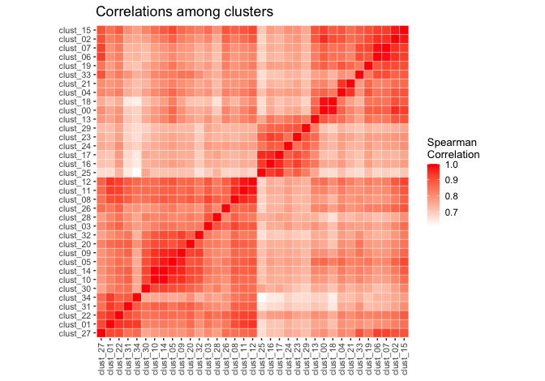

```r
# build correlation matrix from expression data
cor.matrix <- cor(plac %>% select(starts_with("clust")), method = 'spearman')

# reorder correlation matrix based on clustering
dd <- as.dist((1 - cor.matrix))
hc <- hclust(dd, method = 'complete')
cormat <- cor.matrix[hc$order, hc$order]

# melt correlation matrix
dat <- reshape2::melt(cormat, na.rm = T)

## plot
p <- ggplot(data = dat, aes(Var1, Var2, fill = value)) +
  geom_tile(colour = "white") +
  scale_fill_gradient(low = 'white', high = 'red',
                      name = "Spearman\nCorrelation") +
  coord_fixed(ratio = 1) +
  labs(title = "Correlations among clusters") +
  theme_bw() +
  theme(axis.text.x = element_text(angle = 90, size = 8,
                                   hjust=1, vjust = 0.5),
        axis.text.y = element_text(size=8),
        axis.ticks.length = unit(0.15, units = c('lines')),
        legend.title = element_text(size = 10),
        axis.title = element_blank(),
        panel.grid = element_blank(),
        panel.border = element_blank(),
        legend.key.size = unit(0.8, units = c('lines')))

ggsave(p, filename = "../results/02_annotation/plots/corrplot_clusters.pdf",
       device = "pdf", width = 7, height = 6, units = "in")

print(p)
```

## 2.2 Heirarchical clustering

```r
# build correlation matrix from expression data
cor.matrix <- cor(plac %>% select(starts_with("clust")), method = 'spearman')

# reorder correlation matrix based on clustering
dd <- as.dist((1 - cor.matrix))
hc <- hclust(dd, method = 'complete')

pdf(file = "../results/02_annotation/plots/hclust_clusters.pdf", width = 7, height = 5)
plot(hc, cex = 0.8)
dev.off()
```

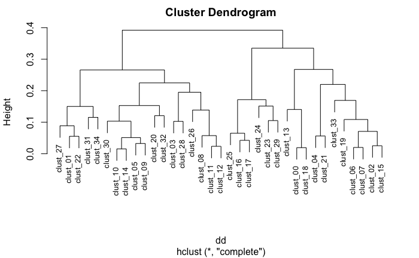

```r
plot(hc, cex = 0.8)
```

There are three big cluster blocks, with substructure within them. The cluster blocks also correspond well with the UMAP plot that was sent by Alice.

# 3 Annotation by correlation

Let’s now actually measure correlations between all clusters with the reference datasets. We will treat our data as query dataset and for each cluster assign top 3 cell types in each reference dataset.

```r
refdata <- c("vento", "surya", "pavli")

# build correlation matrix from expression data
cor.matrix <- cor(plac[, names(plac)[names(plac) != "gene_name"]],
                  method = 'spearman')

# reorder correlation matrix based on clustering
dd <- as.dist((1 - cor.matrix))
hc <- hclust(dd, method = 'complete')
cor.matrix <- cor.matrix[hc$order, hc$order]

# melt correlation matrix
cormat <- reshape2::melt(cor.matrix, na.rm = T)
cormat$Var1_source <- sapply(strsplit(as.character(cormat$Var1), split = "_"), "[[", 1)
cormat$Var2_source <- sapply(strsplit(as.character(cormat$Var2), split = "_"), "[[", 1)

# subset
cormat <- cormat[which(cormat$Var1_source %in% refdata &
                   cormat$Var2_source == "clust"), ]

# top 3 matches with highest correlation coefficients
topmatch <- data.frame( # empty df to fill top matches from the loop below
  cluster = unique(as.character(cormat$Var2)) %>% sort(),
  vento.top1 = NA,
  surya.top1 = NA,
  pavli.top1 = NA,
  vento.top2 = NA,
  surya.top2 = NA,
  pavli.top2 = NA,
  vento.top3 = NA,
  surya.top3 = NA,
  pavli.top3 = NA
)

cormat$top3 <- NA

for(i in unique(cormat$Var2)){
  for(j in refdata){
    # identify top3 match indices
    ind <- which(cormat$Var2 == i & cormat$Var1_source == j)
    val <- cormat$value[ind]
    top3ind <- ind[order(val, decreasing = TRUE)[1:3]]

    # assign match ranking to correlation data for plotting
    cormat$top3[top3ind[1]] <- "1"
    cormat$top3[top3ind[2]] <- "2"
    cormat$top3[top3ind[3]] <- "3"

    # assign top matches to topmatches dataframe
    topmatch[topmatch$cluster == i, paste0(j, ".top1")] <- gsub(paste0(j, "_"), "", as.character(cormat$Var1[top3ind[1]]))
    topmatch[topmatch$cluster == i, paste0(j, ".top2")] <- gsub(paste0(j, "_"), "", as.character(cormat$Var1[top3ind[2]]))
    topmatch[topmatch$cluster == i, paste0(j, ".top3")] <- gsub(paste0(j, "_"), "", as.character(cormat$Var1[top3ind[3]]))
  }
}
```

## 3.1 Plots

```r
# plotting function
clustAnnoPlot <- function(dat, query, reference){

  dat <- dat[which(dat$Var2_source == query & dat$Var1_source == reference), ]

  p <- ggplot(data = dat,
              aes(Var1, Var2, fill = value)) +
    geom_tile(colour = "white") +
    scale_fill_gradient(low = 'white', high = 'red',
                        name = "Spearman\nCorrelation") +
    geom_point(aes(Var1, Var2, alpha = top3),
               size = 1.5, shape = 19, stroke  = 0) +
    scale_alpha_manual(values = c(1, 0.5, 0.25),
                       breaks = c(1, 2, 3),
                       name = "top3", na.value = 0) +
    coord_fixed(ratio = 1) +
    xlab("reference") +
    ylab("query") +
    labs(caption = "For each celltype in query, black points represent top 3 celltypes from reference with highest correlation.",
         title = paste0(query, " vs. ", reference)) +
    theme_bw() +
    theme(axis.text.x = element_text(angle = 90, size = 8,
                                     hjust=1, vjust = 0.5),
          axis.text.y = element_text(size=8),
          axis.ticks.length = unit(0.15, units = c('lines')),
          legend.title = element_text(size = 10),
          axis.title = element_text(size = 8),
          plot.caption = element_text(size = 7),
          panel.grid = element_blank(),
          panel.border = element_blank(),
          legend.key.size = unit(0.8, units = c('lines')))

  return(p)
}
```

### 3.1.1 Against Vento-Tormo et al

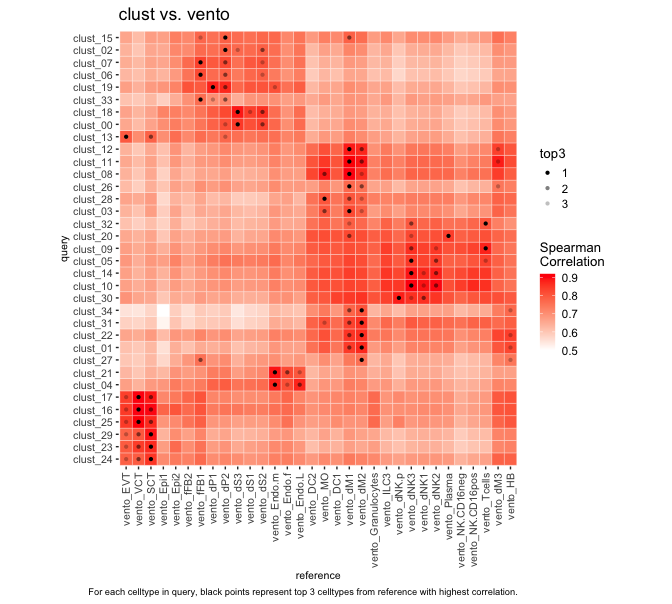

```r
## Annotation plots
anno.vento <- clustAnnoPlot(dat = cormat, query = "clust", reference = "vento")
cowplot::ggsave2(anno.vento, device = "pdf", width = 7.5, height = 6.5, units = "in",
                 filename = "../results/02_annotation/plots/annotation-by-correlation_ref-vento.pdf")
print(anno.vento)
```

### 3.1.2 Against Suryavanshi et al

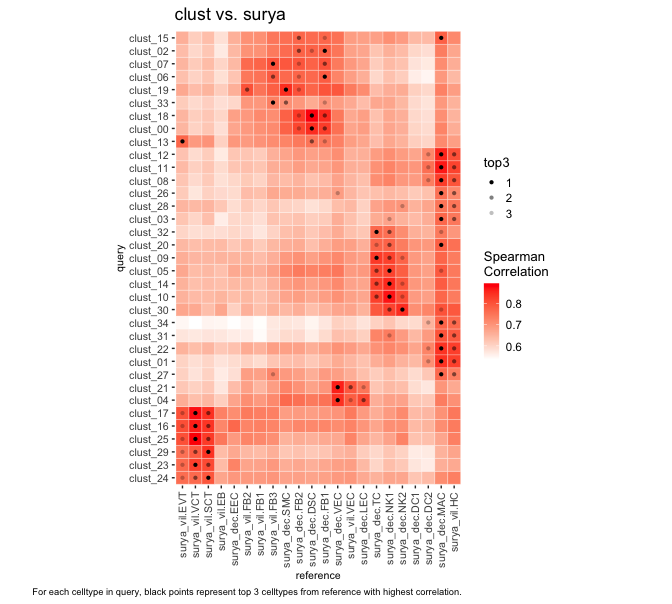

```r
## Annotation plots
anno.surya <- clustAnnoPlot(dat = cormat, query = "clust", reference = "surya")
cowplot::ggsave2(anno.surya, device = "pdf", width = 7.5, height = 6.5, units = "in",
                 filename = "../results/02_annotation/plots/annotation-by-correlation_ref-surya.pdf")
print(anno.surya)
```

### 3.1.3 Against Pavlicev et al

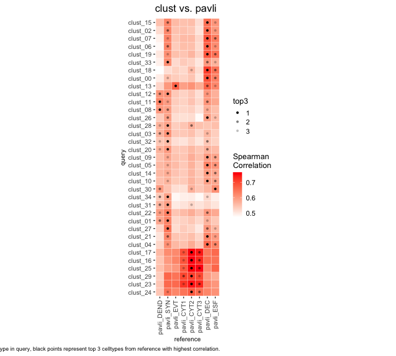

```r
## Annotation plots
anno.pavli <- clustAnnoPlot(dat = cormat, query = "clust", reference = "pavli")
cowplot::ggsave2(anno.pavli, device = "pdf", width = 7, height = 6, units = "in",
                 filename = "../results/02_annotation/plots/annotation-by-correlation_ref-pavli.pdf")
print(anno.pavli)
```

## 3.2 Top matches

```r
topmatch %>% kable(caption = "Top 3 matches against all reference datasets.") %>% kable_styling(full_width = FALSE)
```

Top 3 matches against all reference datasets.

| cluster | vento.top1 | surya.top1 | pavli.top1 | vento.top2 | surya.top2 | pavli.top2 | vento.top3 | surya.top3 | pavli.top3 |
| --- | --- | --- | --- | --- | --- | --- | --- | --- | --- |
| clust_00 | dS3 | dec.DSC | DEC | dS2 | dec.FB1 | ESF | dP2 | dec.FB2 | SYN |
| clust_01 | dM2 | dec.MAC | SYN | dM1 | vil.HC | DEND | HB | dec.DC2 | DEC |
| clust_02 | dP2 | dec.FB1 | DEC | dS2 | dec.FB2 | SYN | dS3 | dec.DSC | ESF |
| clust_03 | dM1 | dec.MAC | SYN | MO | vil.HC | DEND | dM2 | dec.NK1 | DEC |
| clust_04 | Endo.m | dec.VEC | DEC | Endo.L | dec.LEC | ESF | Endo.f | vil.VEC | SYN |
| clust_05 | dNK3 | dec.NK1 | DEC | dNK2 | dec.TC | ESF | Tcells | dec.MAC | SYN |
| clust_06 | fFB1 | dec.FB1 | DEC | dP2 | vil.FB3 | SYN | dS2 | dec.FB2 | ESF |
| clust_07 | fFB1 | vil.FB3 | DEC | dP2 | dec.FB1 | ESF | dS2 | dec.FB2 | SYN |
| clust_08 | dM1 | dec.MAC | DEND | MO | vil.HC | SYN | dM2 | dec.DC2 | DEC |
| clust_09 | Tcells | dec.TC | DEC | dNK3 | dec.NK1 | ESF | dNK2 | dec.NK2 | SYN |
| clust_10 | dNK3 | dec.NK1 | DEC | dNK2 | dec.TC | ESF | dNK1 | dec.NK2 | SYN |
| clust_11 | dM1 | dec.MAC | DEND | dM2 | vil.HC | DEC | dM3 | dec.DC2 | SYN |
| clust_12 | dM1 | dec.MAC | SYN | dM2 | vil.HC | DEND | dM3 | dec.DC2 | DEC |
| clust_13 | EVT | vil.EVT | EVT | SCT | dec.DSC | DEC | dP2 | dec.FB1 | ESF |
| clust_14 | dNK3 | dec.NK1 | DEC | dNK2 | dec.TC | ESF | dNK1 | dec.NK2 | SYN |
| clust_15 | dP2 | dec.MAC | DEC | dM1 | dec.FB2 | SYN | fFB1 | dec.FB1 | ESF |
| clust_16 | VCT | vil.VCT | CYT2 | SCT | vil.SCT | CYT3 | EVT | vil.EVT | CYT1 |
| clust_17 | VCT | vil.VCT | CYT2 | SCT | vil.SCT | CYT3 | EVT | vil.EVT | CYT1 |
| clust_18 | dS3 | dec.DSC | DEC | dS2 | dec.FB1 | ESF | dS1 | dec.FB2 | CYT2 |
| clust_19 | dP1 | dec.SMC | DEC | dP2 | vil.FB2 | ESF | Endo.m | dec.FB2 | SYN |
| clust_20 | Plasma | dec.MAC | SYN | dM1 | dec.NK1 | DEC | dNK3 | dec.TC | DEND |
| clust_21 | Endo.m | dec.VEC | DEC | Endo.f | vil.VEC | SYN | Endo.L | dec.LEC | ESF |
| clust_22 | dM2 | dec.MAC | SYN | dM1 | vil.HC | DEC | HB | dec.DC2 | DEND |
| clust_23 | SCT | vil.VCT | CYT2 | VCT | vil.SCT | CYT3 | EVT | vil.EVT | CYT1 |
| clust_24 | SCT | vil.SCT | CYT2 | VCT | vil.VCT | CYT3 | EVT | vil.EVT | SYN |
| clust_25 | VCT | vil.VCT | CYT2 | SCT | vil.SCT | CYT3 | EVT | vil.EVT | CYT1 |
| clust_26 | dM1 | dec.MAC | DEC | dM2 | vil.HC | SYN | dM3 | dec.VEC | ESF |
| clust_27 | dM2 | dec.MAC | SYN | fFB1 | vil.HC | DEC | HB | vil.FB3 | ESF |
| clust_28 | MO | dec.MAC | SYN | dM1 | vil.HC | CYT2 | dM2 | dec.NK2 | DEND |
| clust_29 | SCT | vil.SCT | CYT2 | VCT | vil.VCT | CYT1 | EVT | vil.EVT | CYT3 |
| clust_30 | dNK.p | dec.NK2 | ESF | dNK1 | dec.NK1 | DEND | dNK3 | dec.MAC | CYT2 |
| clust_31 | dM2 | dec.MAC | SYN | dM1 | vil.HC | DEND | MO | dec.NK1 | CYT2 |
| clust_32 | Tcells | dec.TC | SYN | dNK3 | dec.NK1 | DEC | dM1 | dec.MAC | DEND |
| clust_33 | fFB1 | vil.FB3 | SYN | dP2 | dec.SMC | DEC | dP1 | dec.FB1 | ESF |
| clust_34 | dM2 | dec.MAC | SYN | dM1 | vil.HC | DEND | HB | dec.DC2 | DEC |

```r
NA
```

## 3.3 Labels for clusters

We need to create consistent labels for all cell types that we identify. Below is a `list` I created in which the top level objects are labels we will give to the cell types, within which contained are lists of corresponding labels from `vento` and `surya`. These are tentative labels. After the first pass, when we go through the clusters with a fine-toothed comb, we can modify them further. For example, if we have multiple clusters labeled as `dec.Mac` (decidual macrophages), and if those clusters are distinct, we can then break up this label into `dec.Mac1` and `dec.Mac2`.

```r
labs <- list("dec.DSC"    = list("vento.lab" = c("dS1", "dS2", "dS3"),
                                 "surya.lab" = c("dec.DSC", "dec.FB1", "dec.FB2")),
             "dec.DC"     = list("vento.lab" = c("DC1", "DC2"),
                                 "surya.lab" = c("dec.DC1", "dec.DC2")),
             "dec.Mac"    = list("vento.lab" = c("dM1", "dM2", "dM3"),
                                 "surya.lab" = c("dec.MAC")),
             "dec.NK"     = list("vento.lab" = c("dNK.p", "dNK1", "dNK2", "dNK3", "NK.CD16neg", "NK.CD16pos"),
                                 "surya.lab" = c("dec.NK1", "dec.NK2")),
             "dec.SMC"    = list("vento.lab" = c("dP1", "dP2"),
                                 "surya.lab" = c("dec.SMC")),
             "dec.Endo"   = list("vento.lab" = c("Endo.m"),
                                 "surya.lab" = c("dec.VEC")),
             "dec.Epi"    = list("vento.lab" = c("Epi1", "Epi2"),
                                 "surya.lab" = c("dec.EEC")),
             "dec.Tcell"  = list("vento.lab" = c("Tcells"),
                                 "surya.lab" = c("dec.TC")),
             "vil.Endo"   = list("vento.lab" = c("Endo.f"),
                                 "surya.lab" = c("vil.VEC")),
             "vil.EVT"    = list("vento.lab" = c("EVT"),
                                 "surya.lab" = c("vil.EVT")),
             "vil.FB"     = list("vento.lab" = c("fFB1", "fFB2"),
                                 "surya.lab" = c("vil.FB1", "vil.FB2", "vil.FB3")),
             "vil.Hofb"   = list("vento.lab" = c("HB"),
                                 "surya.lab" = c("vil.HC")),
             "vil.SCT"    = list("vento.lab" = c("SCT"),
                                 "surya.lab" = c("vil.SCT")),
             "vil.VCT"    = list("vento.lab" = c("VCT"),
                                 "surya.lab" = c("vil.VCT")),
             "unk.Gran"   = list("vento.lab" = c("Granulocytes"),
                                 "surya.lab" = c()),
             "unk.ILC"    = list("vento.lab" = c("ILC3"),
                                 "surya.lab" = c()),
             "unk.Mono"   = list("vento.lab" = c("MO"),
                                 "surya.lab" = c()),
             "unk.Plasma" = list("vento.lab" = c("Plasma"),
                                 "surya.lab" = c()),
             "unk.EB"     = list("vento.lab" = c(),
                                 "surya.lab" = c("vil.EB")),
             "unk.Endo.L" = list("vento.lab" = c("Endo.L"),
                                 "surya.lab" = c("dec.LEC"))
)
```

## 3.4 Matches consistent between reference datasets

The following clusters have consistent top1 match between `vento` and `surya` references, i.e. they correspond to the same cell type category. The `pavli` reference is too unresolved to be used diagnostically, so we will ignore it for now. For some cell types it is confirmatory, though, e.g. cluster_00 corresponds to DSC in all three references.

```r
# find out which clusters are consistent.
# If vento.top1 and surya.top1 are found in the same item in the labs list, the mapping is consistent.
consistent <- c(NA)
for(i in 1:nrow(topmatch)){
  consistent[i] <- grep(topmatch$vento.top1[i], labs) == grep(topmatch$surya.top1[i], labs)
}

# subset to include consistent set
topmatch.cons <- topmatch %>%
  filter(consistent) %>%
  select(cluster, vento.top1, surya.top1)

# add our tentative labels to the clusters
for(i in 1:nrow(topmatch.cons)){
  topmatch.cons$label[i] <- names(labs)[grep(topmatch.cons$vento.top1[i], labs)]
}

# print
topmatch.cons[order(topmatch.cons$label), ] %>% knitr::kable() %>% kable_styling(full_width = FALSE)
```

|  | cluster | vento.top1 | surya.top1 | label |
| --- | --- | --- | --- | --- |
| 1 | clust_00 | dS3 | dec.DSC | dec.DSC |
| 16 | clust_18 | dS3 | dec.DSC | dec.DSC |
| 4 | clust_04 | Endo.m | dec.VEC | dec.Endo |
| 18 | clust_21 | Endo.m | dec.VEC | dec.Endo |
| 2 | clust_01 | dM2 | dec.MAC | dec.Mac |
| 3 | clust_03 | dM1 | dec.MAC | dec.Mac |
| 7 | clust_08 | dM1 | dec.MAC | dec.Mac |
| 10 | clust_11 | dM1 | dec.MAC | dec.Mac |
| 11 | clust_12 | dM1 | dec.MAC | dec.Mac |
| 19 | clust_22 | dM2 | dec.MAC | dec.Mac |
| 22 | clust_26 | dM1 | dec.MAC | dec.Mac |
| 23 | clust_27 | dM2 | dec.MAC | dec.Mac |
| 26 | clust_31 | dM2 | dec.MAC | dec.Mac |
| 29 | clust_34 | dM2 | dec.MAC | dec.Mac |
| 5 | clust_05 | dNK3 | dec.NK1 | dec.NK |
| 9 | clust_10 | dNK3 | dec.NK1 | dec.NK |
| 13 | clust_14 | dNK3 | dec.NK1 | dec.NK |
| 25 | clust_30 | dNK.p | dec.NK2 | dec.NK |
| 17 | clust_19 | dP1 | dec.SMC | dec.SMC |
| 8 | clust_09 | Tcells | dec.TC | dec.Tcell |
| 27 | clust_32 | Tcells | dec.TC | dec.Tcell |
| 12 | clust_13 | EVT | vil.EVT | vil.EVT |
| 6 | clust_07 | fFB1 | vil.FB3 | vil.FB |
| 28 | clust_33 | fFB1 | vil.FB3 | vil.FB |
| 20 | clust_24 | SCT | vil.SCT | vil.SCT |
| 24 | clust_29 | SCT | vil.SCT | vil.SCT |
| 14 | clust_16 | VCT | vil.VCT | vil.VCT |
| 15 | clust_17 | VCT | vil.VCT | vil.VCT |
| 21 | clust_25 | VCT | vil.VCT | vil.VCT |

## 3.5 Ambiguous clusters

The top1 matches for some clusters with `vento` and `surya` are not the same. The are the clusters that will require a more detailed look to determine their identify.

```r
# subset for ambiguous clusters
topmatch.ambig <- topmatch %>%
  filter(!consistent) %>%
  select(cluster, vento.top1, surya.top1)

# add our labels.
for(i in 1:nrow(topmatch.ambig)){
  topmatch.ambig$label[i] <- paste0(
    names(labs)[grep(topmatch.ambig$vento.top1[i], labs)],
    " or ",
    names(labs)[grep(topmatch.ambig$surya.top1[i], labs)]
    )
}

# print
topmatch.ambig[order(topmatch.ambig$label), ] %>% kable() %>% kable_styling(full_width = FALSE)
```

|  | cluster | vento.top1 | surya.top1 | label |
| --- | --- | --- | --- | --- |
| 1 | clust_02 | dP2 | dec.FB1 | dec.SMC or dec.DSC |
| 3 | clust_15 | dP2 | dec.MAC | dec.SMC or dec.Mac |
| 6 | clust_28 | MO | dec.MAC | unk.Mono or dec.Mac |
| 4 | clust_20 | Plasma | dec.MAC | unk.Plasma or dec.Mac |
| 2 | clust_06 | fFB1 | dec.FB1 | vil.FB or dec.DSC |
| 5 | clust_23 | SCT | vil.VCT | vil.SCT or vil.VCT |

# 4 Annotation refinement

The annotations we have so far are only a starting point. Now we can look at each annotation more carefully to make sure that everything makes sense.

## 4.1 Sample contribution to clusters

One of the ways in which we can refine the clusters further is by knowing which tissue that sample arises from. For example, if a cluster has macrophage gene signature and if most cells in that cluster come from villi samples, we can further narrow down the identity of the cluster to Hofbauer cells. We can do this by simply counting for each cluster how many cells come from decidua vs villi and by calculating the percentage.

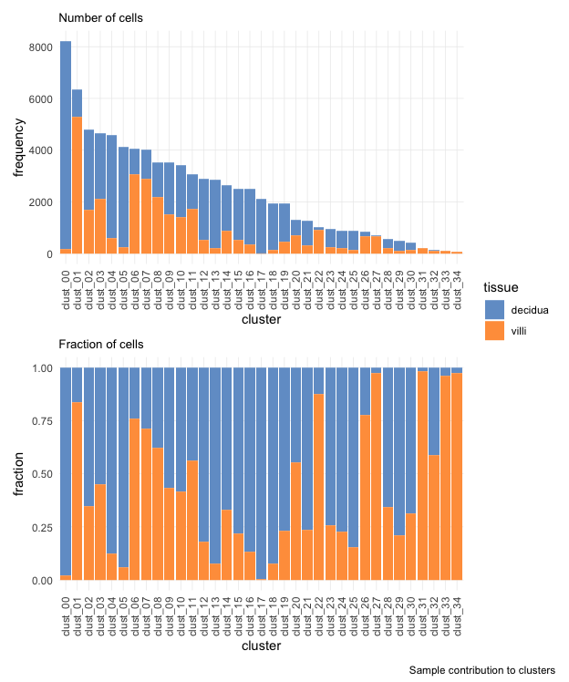

```r
# count cells in each cluster by tissue of origin
bytissue <- table(seur$tissue, seur$seurat_clusters) %>%
  as.data.frame() %>%
  rename(tissue = Var1, cluster = Var2, frequency = Freq)

# calculate fraction
for(i in 1:nrow(bytissue)){
  bytissue$fraction[i] <- bytissue$frequency[i]/
    sum(bytissue$frequency[bytissue$cluster == bytissue$cluster[i]])
}

# plot
p.cells <- ggplot(data = bytissue, aes(x = frequency, y = cluster)) +
  geom_bar(aes(fill = tissue), stat = "identity", position = "stack") +
  ggtitle("Number of cells")

p.frac <- ggplot(data = bytissue, aes(x = fraction, y = cluster)) +
  geom_bar(aes(fill = tissue), stat = "identity", position = "stack") +
  ggtitle("Fraction of cells")

p.cells + p.frac + plot_layout(guides = "collect", nrow = 2) +
  plot_annotation(caption = "Sample contribution to clusters") &
  coord_flip() &
  scale_fill_tableau(palette = "Classic 10 Medium") &
  theme_minimal() +
  theme(panel.grid.minor = element_blank(),
        panel.grid.major = element_line(size = 0.25),
        plot.title = element_text(size = 10),
        axis.text.x = element_text(angle = 90, vjust = 0.5))
```

```r
NA
NA
```

Following clusters have more than 75% cells coming from the same tissue of origin.

```r
bytissue[, c("cluster", "tissue", "fraction")] %>%
  pivot_wider(names_from = "tissue", values_from = "fraction") %>%
  filter(decidua > 0.75 | villi > 0.75) %>%
  kable(digits = 2, row.names = FALSE,
        caption = "Clusters with more than 75% cells from one tissue") %>%
  kable_styling(full_width = FALSE)
```

Clusters with more than 75% cells from one tissue

| cluster | decidua | villi |
| --- | --- | --- |
| clust_00 | 0.98 | 0.02 |
| clust_01 | 0.16 | 0.84 |
| clust_04 | 0.87 | 0.13 |
| clust_05 | 0.94 | 0.06 |
| clust_06 | 0.24 | 0.76 |
| clust_12 | 0.82 | 0.18 |
| clust_13 | 0.93 | 0.07 |
| clust_15 | 0.78 | 0.22 |
| clust_16 | 0.87 | 0.13 |
| clust_17 | 0.99 | 0.01 |
| clust_18 | 0.92 | 0.08 |
| clust_19 | 0.77 | 0.23 |
| clust_21 | 0.76 | 0.24 |
| clust_22 | 0.12 | 0.88 |
| clust_24 | 0.77 | 0.23 |
| clust_25 | 0.85 | 0.15 |
| clust_26 | 0.22 | 0.78 |
| clust_27 | 0.02 | 0.98 |
| clust_29 | 0.79 | 0.21 |
| clust_31 | 0.02 | 0.98 |
| clust_33 | 0.04 | 0.96 |
| clust_34 | 0.03 | 0.97 |

Following clusters have ambiguous origin, i.e. they contain cells from decidua and villi samples.

```r
bytissue[, c("cluster", "tissue", "fraction")] %>%
  pivot_wider(names_from = "tissue", values_from = "fraction") %>%
  filter(decidua < 0.75 & villi < 0.75) %>%
  kable(digits = 2, row.names = FALSE,
        caption = "Clusters with cells from both tissues") %>%
  kable_styling(full_width = FALSE)
```

Clusters with cells from both tissues

| cluster | decidua | villi |
| --- | --- | --- |
| clust_02 | 0.65 | 0.35 |
| clust_03 | 0.55 | 0.45 |
| clust_07 | 0.29 | 0.71 |
| clust_08 | 0.38 | 0.62 |
| clust_09 | 0.57 | 0.43 |
| clust_10 | 0.59 | 0.41 |
| clust_11 | 0.44 | 0.56 |
| clust_14 | 0.67 | 0.33 |
| clust_20 | 0.44 | 0.56 |
| clust_23 | 0.74 | 0.26 |
| clust_28 | 0.66 | 0.34 |
| clust_30 | 0.69 | 0.31 |
| clust_32 | 0.41 | 0.59 |

This doesn’t necessarily clarify too many things. There are many clusters that have over 3/4th of the cells coming from the same tissue, but often not the tissue you expect. For example clusters 16 and 17 are either villous or syncytial trophoblast cells but they are coming mostly from decidua samples. You expect that for cluster 13, which is extravillous trophoblast but not for the other types. At least in the species that I have worked with, it is often difficult to separate the fetal tissue from maternal tissue. So this mixed result could be a result of that difficulty. It looks like we can use this a rough guide, but we can’t necessarily rely of this analysis, i.e. the marker gene should take precedence over tissue of origin in cell type id because the latter is experimentally (and as a consequence, analytically) messy to disentangle.

## 4.2 Marker genes

### 4.2.1 Identify marker genes

I ran `Seurat::findAllMarkers` on this data using the `SCT` assay. This function outputs a list of marker genes for each cluster compared to all other cells in the data. This takes a while (hours) to run, so I ran it on the cluster and saved the results to a `.csv`. See the `code` directory for full code, and see below for the function call.

```r
# set default assay to SCT
DefaultAssay(object = plac) <- "SCT"

# find markers for all clusters
markers <- FindAllMarkers(object = plac,
                          only.pos = TRUE,
                          logfc.threshold = 0.25)

# write.csv
write.csv(markers, "/home/arc78/scratch60/covid-placenta/markers_sct.csv", row.names = FALSE)
```

```r
markers <- read.csv("../results/02_annotation/files/markers_sct.csv")

# rename clusters
markers$cluster <- paste0("clust_", markers$cluster)
markers$cluster <- gsub("(clust_)(\\d)$", "\\10\\2", markers$cluster)
markers$cluster <- factor(markers$cluster, levels = unique(markers$cluster))

# split by cluster
markers <- split.data.frame(markers, markers$cluster)
```

### 4.2.2 Plot marker genes

We will plot top 50 marker genes for all clusters and save the plot to pdf.

```r
# plotting function
DimPlot2 <- function(object = "seur", assay = "SCT", features, title, ...) {
  p <- DotPlot(seur,
               assay = "SCT",
               features = features,
               dot.min = 0.05, dot.scale = 4) +
    coord_flip() +
    labs(caption = paste0(assay, " normalized expression"), title = title) +
    theme_minimal() +
    theme(axis.text.x = element_text(angle = 90, vjust = 0.5, hjust = 1),
          panel.grid = element_blank())

  return(p)
}
```

```r
top50marker.plots <- list()
for(i in names(markers)) {
  if(nrow(markers[[i]]) > 50)
    features <- markers[[i]]$gene[1:50]
  if(nrow(markers[[i]]) < 50)
    features <- markers[[i]]$gene

  top50marker.plots[[i]] <- DimPlot2(features = features, title = i)

  cowplot::ggsave2(top50marker.plots[[i]],
                   filename = paste0("../results/02_annotation/plots/top50markers_dotplot_", i, ".pdf"),
                   width = 7.5, height = 7.5, units = "in")
}
```

## 4.3 Cluster-wise assessment

With the marker gene plots we have made, we can examine the top marker genes in each cluster to manually confirm or adjust the annotation of each cluster.

# 6 References

Pavličev, M., G. P. Wagner, A. R. Chavan, K. Owens, J. Maziarz, C. Dunn-Fletcher, S. G. Kallapur, L. Muglia, and H. Jones. 2017. “Single-Cell Transcriptomics of the Human Placenta: Inferring the Cell Communication Network of the Maternal-Fetal Interface.” *Genome Research*. https://doi.org/10.1101/gr.207597.116.

Suryawanshi, H., P. Morozov, A. Straus, N. Sahasrabudhe, K. E. A. Max, A. Garzia, M. Kustagi, T. Tuschl, and Z. Williams. 2018. “A Single-Cell Survey of the Human First-Trimester Placenta and Decidua.” *Science Advances* 4 (10): eaau4788. https://doi.org/10.1126/sciadv.aau4788.

Vento-Tormo, R., M. Efremova, R. A. Botting, M. Y. Turco, M. Vento-Tormo, K. B. Meyer, J-E. Park, et al. 2018. “Single-Cell Reconstruction of the Early Maternal–Fetal Interface in Humans.” *Nature* 563 (7731): 347–53. https://doi.org/10.1038/s41586-018-0698-6.